# SecondGraph

Michael Turner

2/3/2019

## Types of Comments Reviewers are Making

As marketers approach how to improve the public perception of their drugs they need data. In this case, I was seeking which drugs with more than two reviews had comments that could eaither be classified as positive or negative. To do this I parsed all the comments in the Drugs.com and DrugLib.com datsets for positive phrases and words like: -“Love” -“Saved my life” -“Wonderful”

or negative phrases and words like: -“Hate” -“Ineffective” -“Angry” -“Nightmare”

The I sorted these reviews by each drug and the amount of positive and negative comments as designated by these phrases. This first graph displays the percentage of positive phrases in reviews of those drugs that have more than two reviews. Because it is important for businesses to focus on those products that have the potential to make the most money, I add a line that shows the amount Medicare spent on these pills in 2017 and annotate those points where the product in question accounts for a larger amount of money.

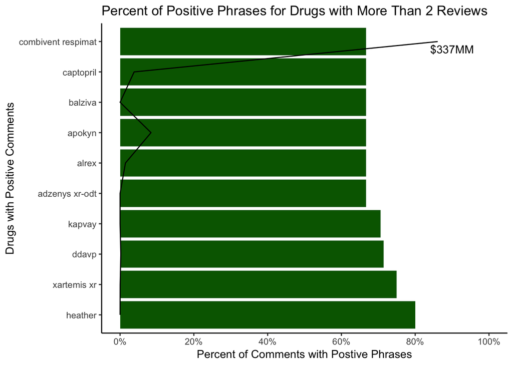

As you can see, Combivent accounts for an overwhelming amount of money compared to the other pills with positive comments. This pill, which treats lung conditions like COPD, is an inhaler that was percribed more than 30MM times for Medicare part D subscribers in 2017. This information might give markets the ability to focus their efforts on selling this particular drug.

The other sie of this coin is to focus on those products with negative reviews to improve public perception. This next graph provides the opposite side of the above graph by focusing on negative comments.

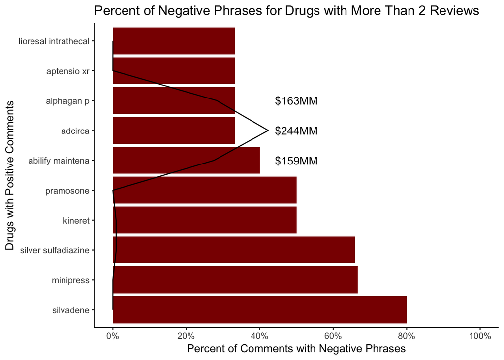

These comments have the potential to affect how users talk to their doctors about the pill they are being prescribed in an attempt to seek out alternative pills.